# Funciones en R

Autor/a

Carlos Lesmes

Fecha de publicación

1 de febrero de 2026

## 1 Introducción

En R, una función es un objeto que encapsula un conjunto de instrucciones para llevar a cabo una tarea. R tiene una vasta colección de funciones incorporadas y también permite a los usuarios crear sus propias funciones y reusarlas.

## 2 Functions incorporadas

R incluye una gran variedad de funciones incorporadas en sus paquetes de base para realizar las operaciones más comunes. Las más populares son:

1. Mathemáticas: abs(), sqrt(), round(), log(), exp(), sin(), cos().
2. Estadísticas: mean(), median(), var(), sd(), min(), max(), sum().
3. Manipulación e inspección de datos: length(), head(), tail(), unique(), subset(), class(), typeof().
4. Entrada/Salida: read.csv(), write.csv(), print(). Usted puede obtener información sobre ualquier función usando `?` seguido por el nombre de la función por ejemplo `?mean`.

Cuando se escribe una función sin `()` R devuelve información sobre la variable.

**Código**

```r
var
```

```
function (x, y = NULL, na.rm = FALSE, use)
{
    if (missing(use))
        use <- if (na.rm)
            "na.or.complete"
        else "everything"
    na.method <- pmatch(use, c("all.obs", "complete.obs", "pairwise.complete.obs",
        "everything", "na.or.complete"))
    if (is.na(na.method))
        stop("invalid 'use' argument")
    if (is.data.frame(x))
        x <- as.matrix(x)
    else if (!is.null(x))
        stopifnot(is.atomic(x))
    if (is.data.frame(y))
        y <- as.matrix(y)
    else if (!is.null(y))
        stopifnot(is.atomic(y))
    .Call(C_cov, x, y, na.method, FALSE)
}
<bytecode: 0x13aee51f0>
<environment: namespace:stats>
```

## 3 Funciones definidas por el usuario

Los usuarios pueden crear sus propias funciones para que no tenga que repetir código.El formato de una función en R es:

```
nombre <- function(parameters){
  cuerpo de la función
}
```

## 4 Ejemplos de Funciones

La siguiente función tiene un parámetro o argumento: `r`, se llama la función con su nombre y el valor en que se quiere calcular.

**Código**

```r
circumferencia <- function(r){
    2*pi*r
}
print(circumferencia(2))
```

```
[1] 12.56637
```

Se puede fijar el valor del parámetro y sellama la función sin valor, o se da un valor diferente e igualmente la función lo calcula.

**Código**

```r
circumferencia1 <- function(r=1){
    2*pi*r
}
print(circumferencia1())
```

```
[1] 6.283185
```

**Código**

```r
print(circumferencia1(2))
```

```
[1] 12.56637
```

Se pueden poner varios parámetros:

**Código**

```r
suma <- function(x, y){
    x + y
}
print(suma(1, 2))
```

```
[1] 3
```

Se puede escribir el cuerpo de la función sin corchetes`{}` si se escribe en una sola línea:

**Código**

```r
suma1 <- function(x, y) x + y
print(suma1(1, 2))
```

```
[1] 3
```

Se pueden usar funciones dentro de una función.

**Código**

```r
media_mediana <- function(vector){
    media <- mean(vector)
    mediana <- median(vector)
    return(c(media, mediana))
}
print(media_mediana(c(1, 1, 1, 2, 3)))
```

```
[1] 1.6 1.0
```

**Código**

```r
resta <- function(x, y){
    x - y
}
print(resta(x=3, y=1))
```

```
[1] 2
```

**Código**

```r
print(resta(y=1, x=3))
```

```
[1] 2
```

**Código**

```r
calorias <- function(peso, estatura, edad=30){
    (10 * peso) + (6.25 * estatura) - (5 * edad) - 161
}
print(calorias(60, 165))
```

```
[1] 1320.25
```

**Código**

```r
f <- function(x,y,z){
  x^2+y^2+z^2
}
body(f)
```

```
{
    x^2 + y^2 + z^2
}
```

**Código**

```r
formals(f)
```

[output not shown]

**Código**

```r
args(f)
```

```
function (x, y, z)
NULL
```

## 5 Funciones con condiciones

**Código**

```r
parOimpar = function(x){
  if(x %% 2 == 0)
    return("par")
  else
    return("impar")
}

print(parOimpar(4))
```

```
[1] "par"
```

**Código**

```r
print(parOimpar(3))
```

```
[1] "impar"
```

**Código**

```r
f = function(x) x^2*4+x/3
print(f(4))
```

```
[1] 65.33333
```

**Código**

```r
print(f(-2))
```

```
[1] 15.33333
```

**Código**

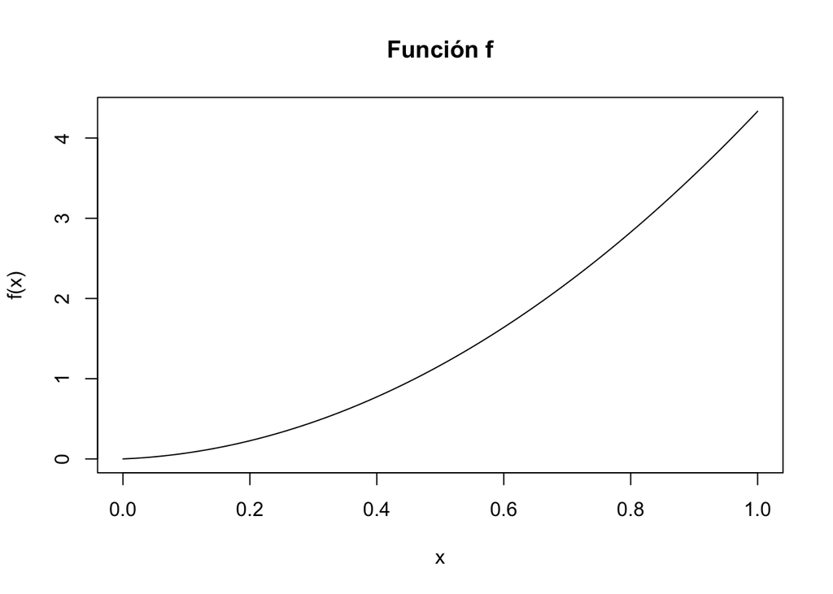

```r
curve(f,main="Función f")
```

## 6 Función genérica, métodos y método de despacho.

Una *función genérica* en R es una función que tiene un comportamiento diferente según el argumento que se le dé. En R, un *método* es una implementación específica de una función genérica que es seleccionado automáticamente y ejecutada basándose en la clase (class) de objeto que se dé. El *método de despacho* es el proceso a usar para seleccionar el método apropiado.

¿A qué clase (class) de objetos le podemos sacar la función `summary`?

**Código**

```r
head(methods(summary),10)
```

```
 [1] "summary.aov"                   "summary.aovlist"
 [3] "summary.aspell"                "summary.check_packages_in_dir"
 [5] "summary.connection"            "summary.data.frame"
 [7] "summary.Date"                  "summary.default"
 [9] "summary.difftime"              "summary.ecdf"
```

¿Es genérica?

**Código**

```r
library(methods)
isGeneric("summary")
```

```
[1] FALSE
```

En R, una función *no genérica* es una función que lleva a cabo un cálculo específico y no cambia su comportamiento de de acuerdo con la clase de sus argumentos.

**Código**

```r
mi_funcion <- function(x) {
  x + 1
}
isGeneric("mi_funcion")
```

```
[1] FALSE
```

**Código**

```r
methods(mi_funcion)
```

```
no methods found
```

## 7 Funciones con el mismo nombre en dos paquetes.

El orden en que R busca las funciones del ambiente (environment) de acuerdo con los paquetes activados:

### 7.1 Búsqueda de objetos en R

**Código**

```r
search()
```

```
[1] ".GlobalEnv"        "package:stats"     "package:graphics"
[4] "package:grDevices" "package:utils"     "package:datasets"
[7] "package:methods"   "Autoloads"         "package:base"
```

```
dplyr::filter()
base::filter()
```

## 8 Pipes

El operador pipeline `|>` (base), `%>%` (magrittr) es útil para concatenar múltiples operaciones. `x %>% f` es equivalente a `f(x)`.

### 8.1 Ejemplos

**Código**

```r
library(magrittr)
log(5)
```

```
[1] 1.609438
```

**Código**

```r
5 %>% log
```

```
[1] 1.609438
```

**Código**

```r
3 %>% sin %>% cos %>% log10()
```

```
[1] -0.004338886
```

**Código**

```r
log10(cos(sin(3)))
```

```
[1] -0.004338886
```

**Código**

```r
iris |> head()
```

| Sepal.Length | Sepal.Width | Petal.Length | Petal.Width | Species |
| --- | --- | --- | --- | --- |
| 5.1 | 3.5 | 1.4 | 0.2 | setosa |
| 4.9 | 3.0 | 1.4 | 0.2 | setosa |
| 4.7 | 3.2 | 1.3 | 0.2 | setosa |
| 4.6 | 3.1 | 1.5 | 0.2 | setosa |
| 5.0 | 3.6 | 1.4 | 0.2 | setosa |
| 5.4 | 3.9 | 1.7 | 0.4 | setosa |

## 9 Funciones que crean funciones

**Código**

```r
potencias <- function(exponente) {
  function(x) {
    x ^ exponente
  }
}
cuadrado <- potencias(2)
cubo <- potencias(3)
#use las nuevas funciones
print(cuadrado(4))
```

```
[1] 16
```

**Código**

```r
print(cubo(4))
```

```
[1] 64
```

## 10 Funciones anónimas

Funciones sin nombre

**Código**

```r
(function(x, y){ z <- x^2 + y^2; x+y+z })(0:7, 1)
```

```
[1]  2  4  8 14 22 32 44 58
```